# Variation in the salience of cultural issues over time and across countries

## Salience of cultural vs economic issues

**OI: At the aggregate level of party systems, cultural issues have been relatively less salient than economic issues throughout the whole studied period.**

##### Comparison of the salience of cultural issues in the aggregate (including multiculturalism, morality, EU, environment, law and order etc.) and aggregate economic issues at the level of elections:

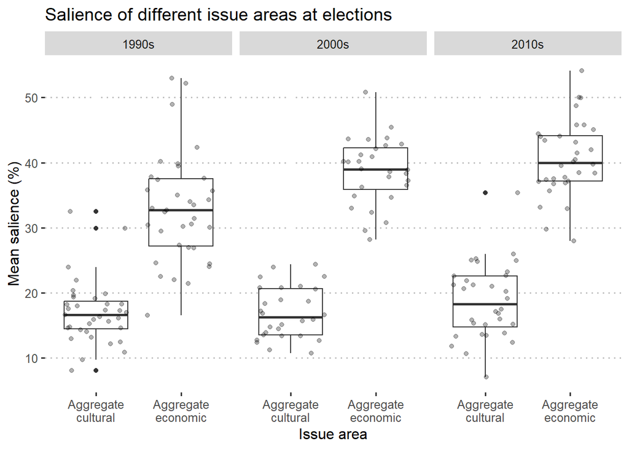

## Is the salience of cultural issues increasing over time?

**OI: The relative salience of cultural issues is increasing over time in CEE party systems.**

##### There are no strong trends in the data:

##### Line graph with loess

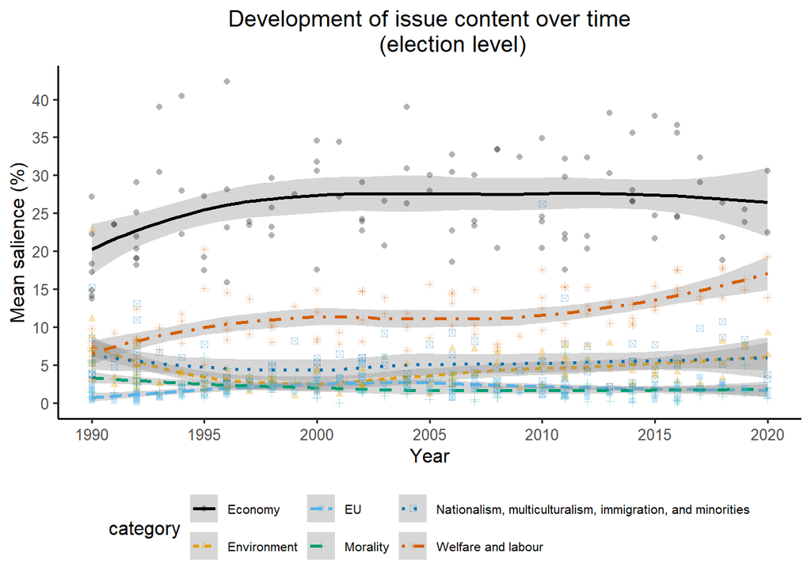

##### OLS of party issue salience on year (country dummies included, not shown):

|  | Multiculturalism | Morality | Environment | EU |
| --- | --- | --- | --- | --- |
| year | -0.00 | -0.05 *** | 0.01 | 0.03 *** |
|  | (0.03) | (0.01) | (0.03) | (0.01) |
| N | 696 | 696 | 696 | 696 |
| R2 | 0.06 | 0.07 | 0.05 | 0.08 |
| Standard errors are heteroskedasticity robust. *** p < 0.001; ** p < 0.01; * p < 0.05. |  |  |  |  |

##### Predictions from the models above:

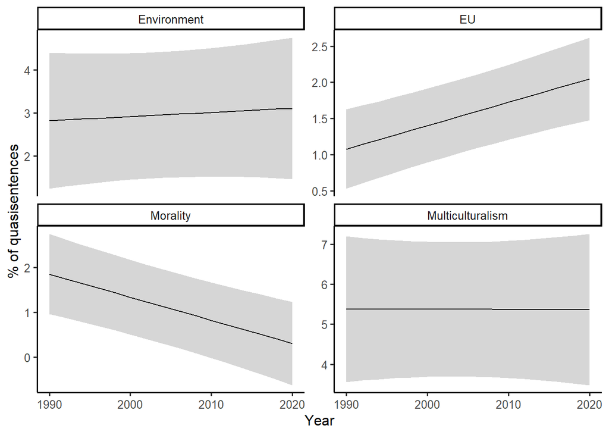

## Was the migration crisis associated with an increase of multiculturalism salience?

**OI: The period following the migration crisis associated with an increase in the salience of multiculturalism and immigration.**

##### Salience of multiculturalism at elections over time:

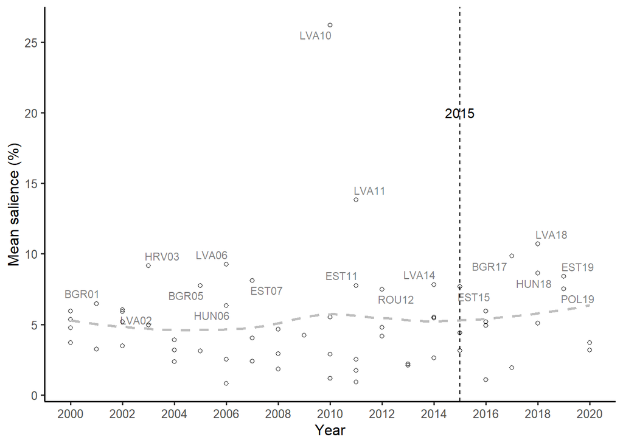

##### Salience of multiculturalism - by country

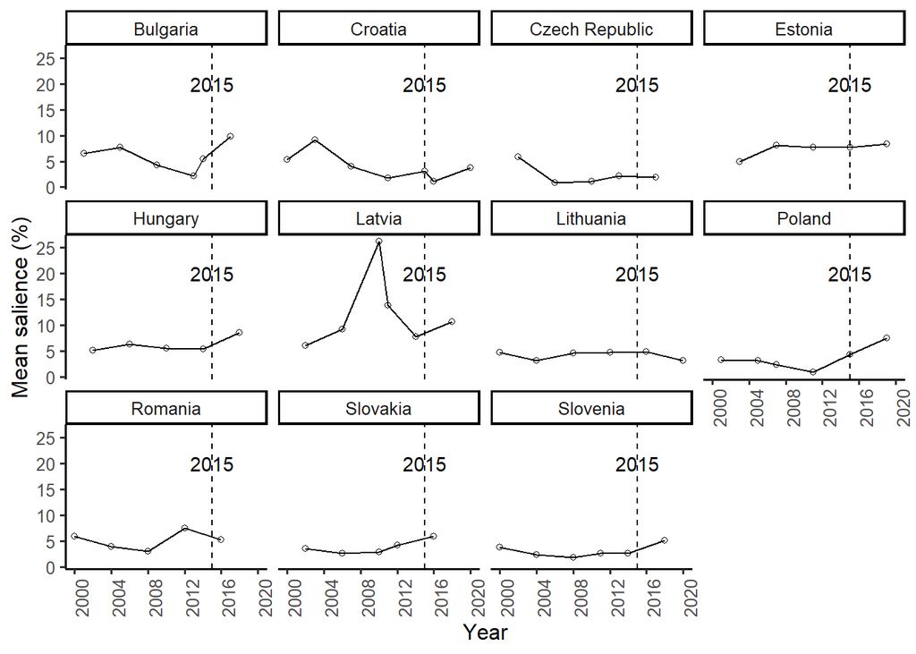

## Does the salience of cultural issues differ conditional on ethnic minorities, religion, or communist legacies?

**OI: The salience of cultural issues should be higher in countries that have politically significant ethnic minorities**

**BUT also in those that have a legacy of national accomodative communism even if ethnic minorities are absent**

##### Country-level plots:

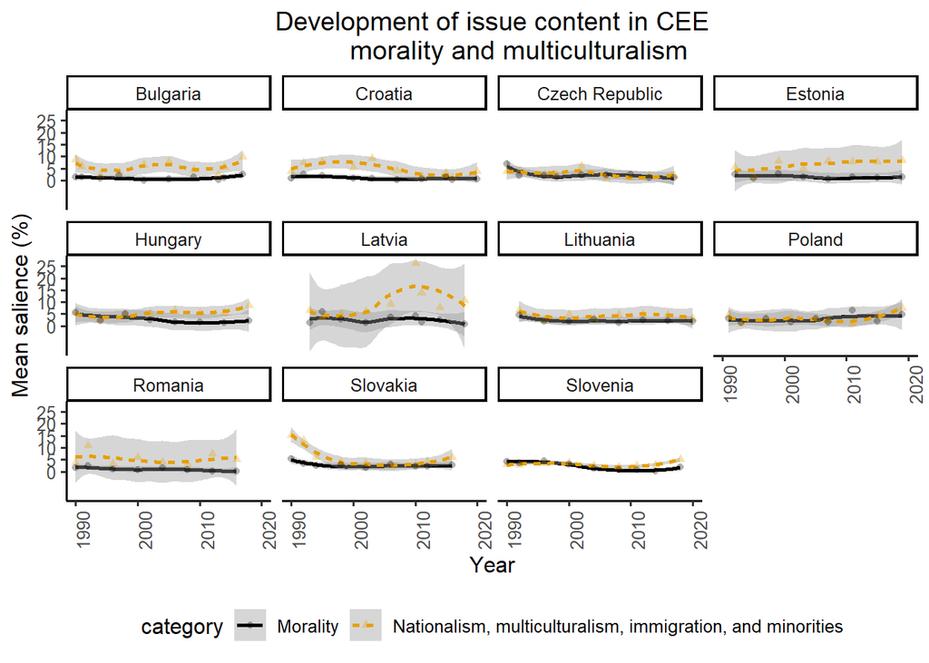

##### Differences in the mean salience of multiculturalism at elections by countries with different communist legacies and ethnic structure:

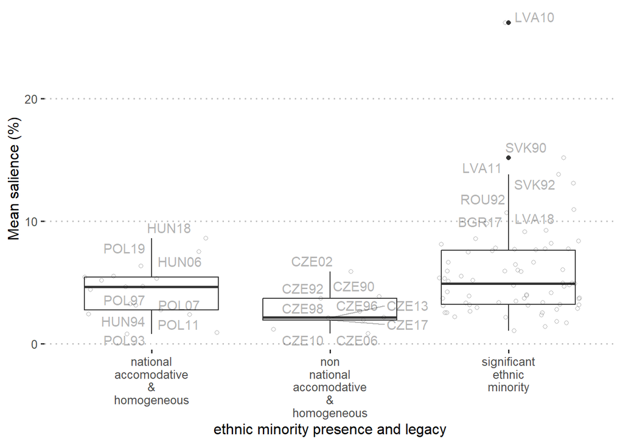

##### Religion and the salience of morality issues

**OI: Countries’ religiosity levels are positively associated with the salience of cultural issues, especially those related to morality.**

There is no significant correlation between countries’ religiosity levels and the salience of morality issues at elections:

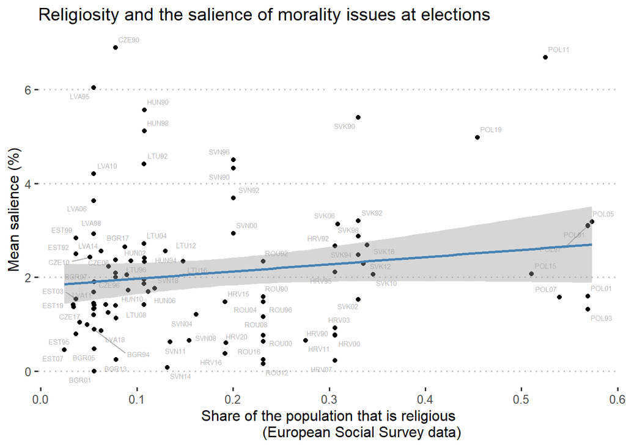

Note: Data on issue salience is from the Manifesto project dataset:

Lehmann, Pola, Simon Franzmann, Denise Al-Gaddooa, Tobias Burst, Christoph Ivanusch, Sven Regel, Felicia Riethmüller, et al. 2024. “Manifesto Project Dataset.” Manifesto Project. https://doi.org/10.25522/MANIFESTO.MPDS.2024A.

Data on religiosity is from the European Social Survey Wave 11 integrated file:

European Social Survey European Research Infrastructure (ESS ERIC). (2024). ESS11 integrated file, edition 2.0 [Data set]. Sikt - Norwegian Agency for Shared Services in Education and Research. https://doi.org/10.21338/ess11e02_0

Communist legacies are coded based on:

Kitschelt, Herbert, Zdenka Mansfeldova, Radoslaw Markowski, and Gabor Toka. 1999. *Post-Communist Party Systems: Competition, Representation, and Inter-Party Cooperation*. Cambridge Studies in Comparative Politics. Cambridge: Cambridge University Press. https://doi.org/10.1017/CBO9781139175173.

Countries with politically significant ethnic minorities are coded based on:

Rovny, Jan. 2024. *Ethnic Minorities, Political Competition, and Democracy: Circumstantial Liberals*. Transformations in Governance. Oxford: Oxford University Press.